# SLAMming with Spheros

##### IPython Notebook with markdown language

To start with, this is my first shot in integrating the agenda, coverage of the entire week as well as the discussion and issues about the thesis. I prefer this way of making the weekly report for a few reasons. The entire document is written using IPython document, which makes it easier for both us since it is easier for an integrated view instead of the overwhelming mail i used to write and it includes Latex which can be later easily added to the future report. Moreover, I can added the entire work into the notebook, which is quite easy from the point of looking at the results rather than sending huge lines of code.

# Weekly report

## Thursday, March $5^{th}$, 2015

### + Meeting with Tamas

```
    -> Using the chariot as such for the SLAM problem
    -> Maze construction
            - Mailed to Kees Slinkman
            - Using reinforced plastic
    -> Comments regarding CV and cover letter
```

### + Tracking with bicycle model

```
    -> EKF tracks the trajectory for simple trajectories
    -> Coding error in estimation using UKF and PF
```

```
Done
```

[output not shown]

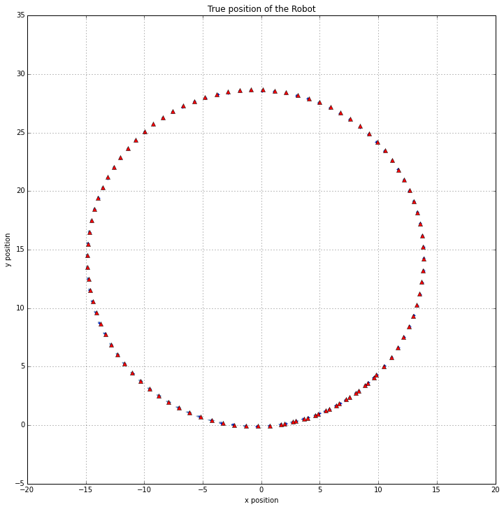

```python
# Written in Python and executed on PowerShell
# help(robot_filter_eup)
%run ekf_python_v0.2_m.ipynb
```

```python
from IPython.core.display import HTML


def css_styling():
    styles = open("../styles/custom.css", "r").read()
    return HTML(styles)
css_styling()
```